# Newton’s Method and Fisher Scoring (KL Chapter 14)

Biostat/Biomath M257

Author

Dr. Hua Zhou @ UCLA

Published

May 9, 2023

System information (for reproducibility):

```julia
versioninfo()
```

```
Julia Version 1.8.5
Commit 17cfb8e65ea (2023-01-08 06:45 UTC)
Platform Info:
  OS: macOS (arm64-apple-darwin21.5.0)
  CPU: 12 × Apple M2 Max
  WORD_SIZE: 64
  LIBM: libopenlibm
  LLVM: libLLVM-13.0.1 (ORCJIT, apple-m1)
  Threads: 8 on 8 virtual cores
Environment:
  JULIA_NUM_THREADS = 8
  JULIA_EDITOR = code
```

Load packages:

```julia
using Pkg

Pkg.activate(pwd())
Pkg.instantiate()
Pkg.status()
```

```
  Activating project at `~/Documents/github.com/ucla-biostat-257/2023spring/slides/23-newton`
```

```
Status `~/Documents/github.com/ucla-biostat-257/2023spring/slides/23-newton/Project.toml`
  [f6369f11] ForwardDiff v0.10.35
  [b964fa9f] LaTeXStrings v1.3.0
  [91a5bcdd] Plots v1.38.11
```

## 1 Notations

Consider maximizing log-likelihood function $L(\mathbf{\theta})$, $\theta \in \Theta \subset \mathbb{R}^p$.

- **Gradient** (or **score**) of $L$:
  $$\nabla L(\theta) = \begin{pmatrix}
  \frac{\partial L(\theta)}{\partial \theta_1} \\
  \vdots \\
  \frac{\partial L(\theta)}{\partial \theta_p}
  \end{pmatrix}$$
- **Hessian** of $L$:
  $$\nabla^2 L(\theta) = \begin{pmatrix}
  \frac{\partial^2 L(\theta)}{\partial \theta_1 \partial \theta_1} & \dots & \frac{\partial^2 L(\theta)}{\partial \theta_1 \partial \theta_p} \\
  \vdots & \ddots & \vdots \\
  \frac{\partial^2 L(\theta)}{\partial \theta_p \partial \theta_1} & \dots & \frac{\partial^2 L(\theta)}{\partial \theta_p \partial \theta_p}
  \end{pmatrix}$$
- **Observed information matrix** (negative Hessian):

$$- \nabla^2 L(\theta)$$

- **Expected (Fisher) information matrix**:
  $$\mathbf{E}[- \nabla^2 L(\theta)].$$

## 2 Newton’s method

- Newton’s method was originally developed for finding roots of nonlinear equations $f(\mathbf{x}) = \mathbf{0}$ (KL 5.4).
- Newton’s method, aka **Newton-Raphson method**, is considered the gold standard for its fast (quadratic) convergence
  $$\frac{\|\mathbf{\theta}^{(t+1)} - \mathbf{\theta}^*\|}{\|\mathbf{\theta}^{(t)} - \mathbf{\theta}^*\|^2} \to \text{constant}.$$
- Idea: iterative quadratic approximation.
- Taylor expansion around the current iterate $\mathbf{\theta}^{(t)}$
  $$L(\mathbf{\theta}) \approx L(\mathbf{\theta}^{(t)}) + \nabla L(\mathbf{\theta}^{(t)})^T (\mathbf{\theta} - \mathbf{\theta}^{(t)}) + \frac 12 (\mathbf{\theta} - \mathbf{\theta}^{(t)})^T [\nabla^2L(\mathbf{\theta}^{(t)})] (\mathbf{\theta} - \mathbf{\theta}^{(t)})$$
  and then maximize the quadratic approximation.
- To maximize the quadratic function, we equate its gradient to zero
  $$\nabla L(\theta^{(t)}) + [\nabla^2L(\theta^{(t)})] (\theta - \theta^{(t)}) = \mathbf{0}_p,$$
  which suggests the next iterate
  $$\begin{eqnarray*}
  \theta^{(t+1)} &=& \theta^{(t)} - [\nabla^2L(\theta^{(t)})]^{-1} \nabla L(\theta^{(t)}) \\
  &=& \theta^{(t)} + [-\nabla^2L(\theta^{(t)})]^{-1} \nabla L(\theta^{(t)}).
  \end{eqnarray*}$$
  We call this **naive Newton’s method**.
- **Stability issue**: naive Newton’s iterate is **not** guaranteed to be an ascent algorithm. It’s equally happy to head uphill or downhill. Following example shows that the Newton iterate converges to a local maximum, converges to a local minimum, or diverges depending on starting points.

```julia
using Plots; gr()
using LaTeXStrings, ForwardDiff

f(x) = sin(x)
df  = x -> ForwardDiff.derivative(f, x) # gradient
d2f = x -> ForwardDiff.derivative(df, x) # hessian
x = 2.0 # start point: 2.0 (local maximum), 2.75 (diverge), 4.0 (local minimum)
titletext = "Starting point: $x"
anim = @animate for iter in 0:10
    iter > 0 && (global x = x - d2f(x) \ df(x))
    p = Plots.plot(f, 0, 2π, xlim=(0, 2π), ylim=(-1.1, 1.1), legend=nothing, title=titletext)
    Plots.plot!(p, [x], [f(x)], shape=:circle)
    Plots.annotate!(p, x, f(x), text(latexstring("x^{($iter)}"), :right))
end
gif(anim, "./tmp.gif", fps = 1);
```

```
[ Info: Saved animation to /Users/huazhou/Documents/github.com/ucla-biostat-257/2023spring/slides/23-newton/tmp.gif
```

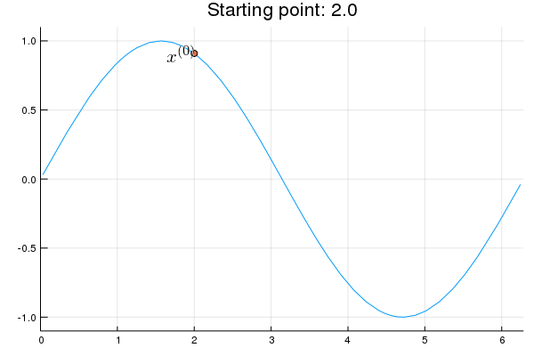

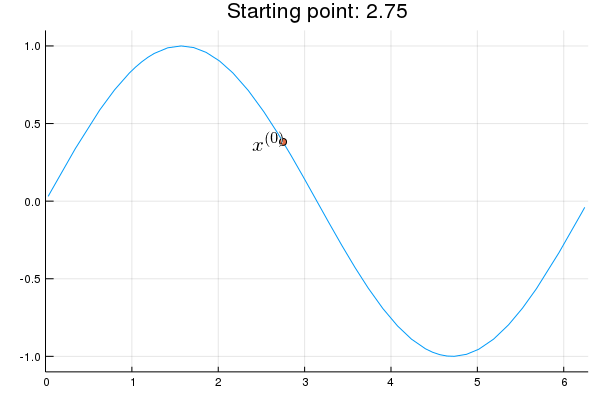

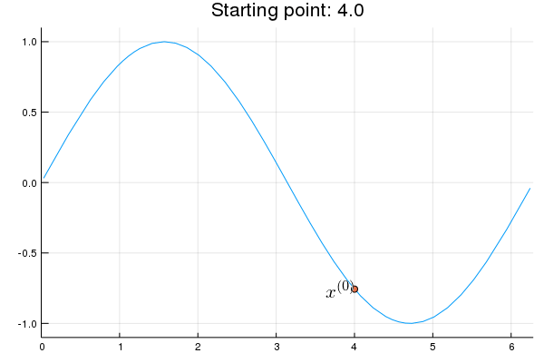

- Remedies for the instability issue:
  1. approximate $-\nabla^2L(\theta^{(t)})$ by a positive definite $\mathbf{A}$ (if it’s not), **and**
  2. line search (backtracking).
- Why insist on a *positive definite* approximation of Hessian? By first-order Taylor expansion,
  $$\begin{eqnarray*}
  & & L(\theta^{(t)} + s \Delta \theta^{(t)}) - L(\theta^{(t)}) \\
  &=& L(\theta^{(t)}) + s \cdot \nabla L(\theta^{(t)})^T \Delta \theta^{(t)} + o(s) - L(\theta^{(t)}) \\
  &=& s \cdot \nabla L(\theta^{(t)})^T \Delta \theta^{(t)} + o(s) \\
  &=& s \cdot \nabla L(\theta^{(t)})^T [\mathbf{A}^{(t)}]^{-1} \nabla L(\theta^{(t)}) + o(s).
  \end{eqnarray*}$$
  For $s$ sufficiently small, right hand side is strictly positive when $\mathbf{A}^{(t)}$ is positive definite. The quantity $\{\nabla L(\theta^{(t)})^T [\mathbf{A}^{(t)}]^{-1} \nabla L(\theta^{(t)})\}^{1/2}$ is termed the **Newton decrement**.
- In summary, a **practical Newton-type algorithm** iterates according to
  $$\boxed{ \theta^{(t+1)} = \theta^{(t)} + s [\mathbf{A}^{(t)}]^{-1} \nabla L(\theta^{(t)})
  = \theta^{(t)} + s \Delta \theta^{(t)} }$$
  where $\mathbf{A}^{(t)}$ is a pd approximation of $-\nabla^2L(\theta^{(t)})$ and $s$ is a step length.
- For strictly concave $L$, $-\nabla^2L(\theta^{(t)})$ is always positive definite. Line search is still needed to guarantee convergence.
- Line search strategy: step-halving ($s=1,1/2,\ldots$), golden section search, cubic interpolation, Amijo rule, … Note the **Newton direction**
  $$\Delta \theta^{(t)} = [\mathbf{A}^{(t)}]^{-1} \nabla L(\theta^{(t)})$$
  only needs to be calculated once. Cost of line search mainly lies in objective function evaluation.
- How to approximate $-\nabla^2L(\theta)$? More of an art than science. Often requires problem specific analysis.
- Taking $\mathbf{A} = \mathbf{I}$ leads to the method of **steepest ascent**, aka **gradient ascent**.

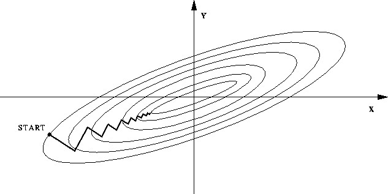

## 3 Fisher’s scoring method

- **Fisher’s scoring method**: replace $- \nabla^2L(\theta)$ by the expected Fisher information matrix
  $$\mathbf{FIM}(\theta) = \mathbf{E}[-\nabla^2L(\theta)] = \mathbf{E}[\nabla L(\theta) \nabla L(\theta)^T] \succeq \mathbf{0}_{p \times p},$$
  which is psd under exchangeability of expectation and differentiation.

  Therefore the Fisher’s scoring algorithm iterates according to
  $$\boxed{ \theta^{(t+1)} = \theta^{(t)} + s [\mathbf{FIM}(\theta^{(t)})]^{-1} \nabla L(\theta^{(t)})}.$$

## 4 Generalized linear model (GLM) (KL 14.7)

### 4.1 Logistic regression

Let’s consider a concrete example: logistic regression.

- The goal is to predict whether a credit card transaction is fraud ($y_i=1$) or not ($y_i=0$). Predictors ($\mathbf{x}_i$) include: time of transaction, last location, merchant, …
- $y_i \in \{0,1\}$, $\mathbf{x}_i \in \mathbb{R}^{p}$. Model $y_i $Bernoulli$(p_i)$.
- Logistic regression. Density
  $$\begin{eqnarray*}
  f(y_i|p_i) &=& p_i^{y_i} (1-p_i)^{1-y_i} \\
  &=& e^{y_i \ln p_i + (1-y_i) \ln (1-p_i)} \\
  &=& e^{y_i \ln \frac{p_i}{1-p_i} + \ln (1-p_i)},
  \end{eqnarray*}$$
  where
  $$\begin{eqnarray*}
  \mathbf{E} (y_i) = p_i &=& \frac{e^{\eta_i}}{1+ e^{\eta_i}} \quad \text{(mean function, inverse link function)} \\
  \eta_i = \mathbf{x}_i^T \beta &=& \ln \left( \frac{p_i}{1-p_i} \right) \quad \text{(logit link function)}.
  \end{eqnarray*}$$
- Given data $(y_i,\mathbf{x}_i)$, $i=1,\ldots,n$,

$$\begin{eqnarray*}
L_n(\beta) &=& \sum_{i=1}^n \left[ y_i \ln p_i + (1-y_i) \ln (1-p_i) \right] \\
&=& \sum_{i=1}^n \left[ y_i \mathbf{x}_i^T \beta - \ln (1 + e^{\mathbf{x}_i^T \beta}) \right] \\
\nabla L_n(\beta) &=& \sum_{i=1}^n \left( y_i \mathbf{x}_i - \frac{e^{\mathbf{x}_i^T \beta}}{1+e^{\mathbf{x}_i^T \beta}} \mathbf{x}_i \right) \\
&=& \sum_{i=1}^n (y_i - p_i) \mathbf{x}_i = \mathbf{X}^T (\mathbf{y} - \mathbf{p}) \\
- \nabla^2L_n(\beta) &=& \sum_{i=1}^n p_i(1-p_i) \mathbf{x}_i \mathbf{x}_i^T = \mathbf{X}^T \mathbf{W} \mathbf{X}, \quad
\text{where } \mathbf{W} &=& \text{diag}(w_1,\ldots,w_n), w_i = p_i (1-p_i) \\
\mathbf{FIM}_n(\beta) &=& \mathbf{E} [- \nabla^2L_n(\beta)] = - \nabla^2L_n(\beta).
\end{eqnarray*}$$

- Newton’s method == Fisher’s scoring iteration:
  $$\begin{eqnarray*}
  \beta^{(t+1)} &=& \beta^{(t)} + s[-\nabla^2 L(\beta^{(t)})]^{-1} \nabla L(\beta^{(t)}) \\
  &=& \beta^{(t)} + s(\mathbf{X}^T \mathbf{W}^{(t)} \mathbf{X})^{-1} \mathbf{X}^T (\mathbf{y} - \mathbf{p}^{(t)}) \\
  &=& (\mathbf{X}^T \mathbf{W}^{(t)} \mathbf{X})^{-1} \mathbf{X}^T \mathbf{W}^{(t)} \left[ \mathbf{X} \beta^{(t)} + s(\mathbf{W}^{(t)})^{-1} (\mathbf{y} - \mathbf{p}^{(t)}) \right] \\
  &=& (\mathbf{X}^T \mathbf{W}^{(t)} \mathbf{X})^{-1} \mathbf{X}^T \mathbf{W}^{(t)} \mathbf{z}^{(t)},
  \end{eqnarray*}$$
  where
  $$\mathbf{z}^{(t)} = \mathbf{X} \beta^{(t)} + s(\mathbf{W}^{(t)})^{-1} (\mathbf{y} - \mathbf{p}^{(t)})$$
  are the working responses. A Newton’s iteration is equivalent to solving a weighed least squares problem $\sum_{i=1}^n w_i (z_i - \mathbf{x}_i^T \beta)^2$. Thus the name **IRWLS (iteratively re-weighted least squares)**.

### 4.2 GLM

Let’s consider the more general class of generalized linear models (GLM).

| Family | Canonical Link | Variance Function |
| --- | --- | --- |
| Normal | $\eta=\mu$ | 1 |
| Poisson | $\eta=\log \mu$ | $\mu$ |
| Binomial | $\eta=\log \left( \frac{\mu}{1 - \mu} \right)$ | $\mu (1 - \mu)$ |
| Gamma | $\eta = \mu^{-1}$ | $\mu^2$ |
| Inverse Gaussian | $\eta = \mu^{-2}$ | $\mu^3$ |

- $Y$ belongs to an exponential family with density
  $$p(y|\theta,\phi) = \exp \left\{ \frac{y\theta - b(\theta)}{a(\phi)} + c(y,\phi) \right\}.$$
  - $\theta$: natural parameter.
  - $\phi>0$: dispersion parameter.
    GLM relates the mean $\mu = \mathbf{E}(Y|\mathbf{x})$ via a strictly increasing link function
    $$g(\mu) = \eta = \mathbf{x}^T \beta, \quad \mu = g^{-1}(\eta)$$
- Score, Hessian, information

$$\begin{eqnarray*}
\nabla L_n(\beta) &=& \sum_{i=1}^n \frac{(y_i-\mu_i) \mu_i'(\eta_i)}{\sigma_i^2} \mathbf{x}_i \\
\,- \nabla^2 L_n(\boldsymbol{\beta}) &=& \sum_{i=1}^n \frac{[\mu_i'(\eta_i)]^2}{\sigma_i^2} \mathbf{x}_i \mathbf{x}_i^T - \sum_{i=1}^n \frac{(y_i - \mu_i) \mu_i''(\eta_i)}{\sigma_i^2} \mathbf{x}_i \mathbf{x}_i^T \\
& & + \sum_{i=1}^n \frac{(y_i - \mu_i) [\mu_i'(\eta_i)]^2 (d \sigma_i^{2} / d\mu_i)}{\sigma_i^4} \mathbf{x}_i \mathbf{x}_i^T \\
\mathbf{FIM}_n(\beta) &=& \mathbf{E} [- \nabla^2 L_n(\beta)] = \sum_{i=1}^n \frac{[\mu_i'(\eta_i)]^2}{\sigma_i^2} \mathbf{x}_i \mathbf{x}_i^T = \mathbf{X}^T \mathbf{W} \mathbf{X}.
\end{eqnarray*}$$

- Fisher scoring method
  $$\beta^{(t+1)} = \beta^{(t)} + s [\mathbf{FIM}(\beta^{(t)})]^{-1} \nabla L_n(\beta^{(t)})$$
  IRWLS with weights $w_i = [\mu_i(\eta_i)]^2/\sigma_i^2$ and some working responses $z_i$.
- For **canonical link**, $\theta = \eta$, the second term of Hessian vanishes and Hessian coincides with Fisher information matrix. Convex problem 😄
  $$\text{Fisher's scoring == Newton's method}.$$
- Non-canonical link, non-convex problem 😞
  $$\text{Fisher's scoring algorithm} \ne \text{Newton's method}.$$
  Example: Probit regression (binary response with probit link).
  $$\begin{eqnarray*}
  y_i &\sim& \text{Bernoulli}(p_i) \\
  p_i &=& \Phi(\mathbf{x}_i^T \beta) \\
  \eta_i &=& \mathbf{x}_i^T \beta = \Phi^{-1}(p_i).
  \end{eqnarray*}$$
  where $\Phi(\cdot)$ is the cdf of a standard normal.
- Julia, R and Matlab implement the Fisher scoring method, aka IRWLS, for GLMs.
  - GLM.jl package.

## 5 Nonlinear regression - Gauss-Newton method (KL 14.4-14.6)

- Now we finally get to the problem Gauss faced in 1800!  
  Relocate Ceres by fitting 41 observations to a 6-parameter (nonlinear) orbit.
- Nonlinear least squares (curve fitting):
  $$\text{minimize} \,\, f(\beta) = \frac{1}{2} \sum_{i=1}^n [y_i - \mu_i(\mathbf{x}_i, \beta)]^2$$
  For example, $y_i =$ dry weight of onion and $x_i=$ growth time, and we want to fit a 3-parameter growth curve
  $$\mu(x, \beta_1,\beta_2,\beta_3) = \frac{\beta_3}{1 + e^{-\beta_1 - \beta_2 x}}.$$

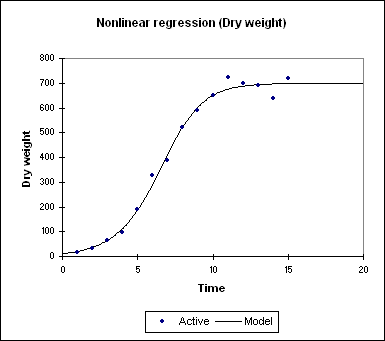

- “Score” and “information matrices”
  $$\begin{eqnarray*}
  \nabla f(\beta) &=& - \sum_{i=1}^n [y_i - \mu_i(\beta)] \nabla \mu_i(\beta) \\
  \nabla^2 f(\beta) &=& \sum_{i=1}^n \nabla \mu_i(\beta) \nabla \mu_i(\beta)^T - \sum_{i=1}^n [y_i - \mu_i(\beta)] \nabla^2 \mu_i(\beta) \\
  \mathbf{FIM}(\beta) &=& \sum_{i=1}^n \nabla \mu_i(\beta) \nabla \mu_i(\beta)^T = \mathbf{J}(\beta)^T \mathbf{J}(\beta),
  \end{eqnarray*}$$
  where $\mathbf{J}(\beta)^T = [\nabla \mu_1(\beta), \ldots, \nabla \mu_n(\beta)] \in \mathbb{R}^{p \times n}$.
- **Gauss-Newton** (= “Fisher’s scoring algorithm”) uses $\mathbf{I}(\beta)$, which is always psd.
  $$\boxed{ \beta^{(t+1)} = \beta^{(t)} + s [\mathbf{FIM} (\beta^{(t)})]^{-1} \nabla L(\beta^{(t)}) }$$
- **Levenberg-Marquardt** method, aka **damped least squares algorithm (DLS)**, adds a ridge term to the approximate Hessian
  $$\boxed{ \beta^{(t+1)} = \beta^{(t)} + s [\mathbf{FIM} (\beta^{(t)}) + \tau \mathbf{I}_p]^{-1} \nabla L(\beta^{(t)}) }$$
  bridging between Gauss-Newton and steepest descent.
- Other approximation to Hessians: nonlinear GLMs.  
  See KL 14.4 for examples.